# Practical Machine learning Final Project - 4/22/2016

### Executive summary

The goal of your project is to predict the manner in which they did the exercise. This is the “classe” variable in the training set. You may use any of the other variables to predict with. You should create a report describing how you built your model, how you used cross validation, what you think the expected out of sample error is, and why you made the choices you did. You will also use your prediction model to predict 20 different test cases

### Analysis

```r
#load required libraries
pacman::p_load(dplyr,funModeling,caret,data.table,rpart,randomForest,rattle,gbm)

#Set seed to make the report reproducible
set.seed(12345)
#---------------------------------- DATA PRE-PROCESSNG----------------------------------------------
#load the training and test sets and drop ID variables
traindata <- fread("pml-training.csv",na.strings=c("NA","#DIV/0!", "")) %>% select(-V1)
testdata <- fread("pml-testing.csv", na.strings=c("NA","#DIV/0!", "")) %>% select(-V1)
```

```r
summ <- df_status(traindata)
```

```
##                     variable q_zeros p_zeros  q_na   p_na      type unique
## 1                  user_name       0    0.00     0   0.00 character      6
## 2       raw_timestamp_part_1       0    0.00     0   0.00   integer    837
## 3       raw_timestamp_part_2       0    0.00     0   0.00   integer  16783
## 4             cvtd_timestamp       0    0.00     0   0.00 character     20
## 5                 new_window       0    0.00     0   0.00 character      2
## 6                 num_window       0    0.00     0   0.00   integer    858
## 7                  roll_belt       5    0.03     0   0.00   numeric   1330
## 8                 pitch_belt       1    0.01     0   0.00   numeric   1840
## 9                   yaw_belt       3    0.02     0   0.00   numeric   1957
## 10          total_accel_belt       3    0.02     0   0.00   integer     29
## 11        kurtosis_roll_belt       0    0.00 19226  97.98   numeric    395
## 12       kurtosis_picth_belt       0    0.00 19248  98.09   numeric    315
## 13         kurtosis_yaw_belt       0    0.00 19622 100.00   logical      0
## 14        skewness_roll_belt       4    0.02 19225  97.98   numeric    393
```

[output cut: 145 more lines]

```r
head(summ)
```

```
##               variable q_zeros p_zeros q_na p_na      type unique
## 1            user_name       0       0    0    0 character      6
## 2 raw_timestamp_part_1       0       0    0    0   integer    837
## 3 raw_timestamp_part_2       0       0    0    0   integer  16783
## 4       cvtd_timestamp       0       0    0    0 character     20
## 5           new_window       0       0    0    0 character      2
## 6           num_window       0       0    0    0   integer    858
```

Let’s partition the training set into train and test sets and set the training parameters

```r
#remove variables with more than 70% of missing values
vars_to_exclude <- filter(summ, p_na > 70)
traindata[, (vars_to_exclude$variable) := NULL]

#Partition the training data into train and test sets
inTrain <- createDataPartition(y=traindata$classe, p=0.6, list=FALSE)
trainset<- traindata[inTrain,]; testset <- traindata[-inTrain,]

#Remove variables with variables with low variance as they may have less predictive power
nzVars <- nearZeroVar(trainset, saveMetrics = TRUE)
#re-setting the trainset after near zero variance removal
trainset <- trainset[!nzVars$nzv]
#Let's try to reduce the number of predictors,i.e, select the principal components using pca
preProc <- preProcess(trainset, method=c("center", "scale", "pca"),thresh=0.8)
#predict trainset and testset based on the pca object
trainsetPC <- predict(preProc,trainset)
testsetPC <- predict(preProc,testset)
#Setting up all training parameters
ctrl <- trainControl(method="repeatedcv",number = 10, repeats = 2)
```

## Train model

```r
#I will use first the random forest and a generalized boosted trees to model the data
rfFit <- train(classe ~.,data = trainsetPC, method = "rf",trControl = ctrl)
gbmFit <- train(classe ~.,data = trainsetPC, method = "gbm",
              trControl = ctrl)
```

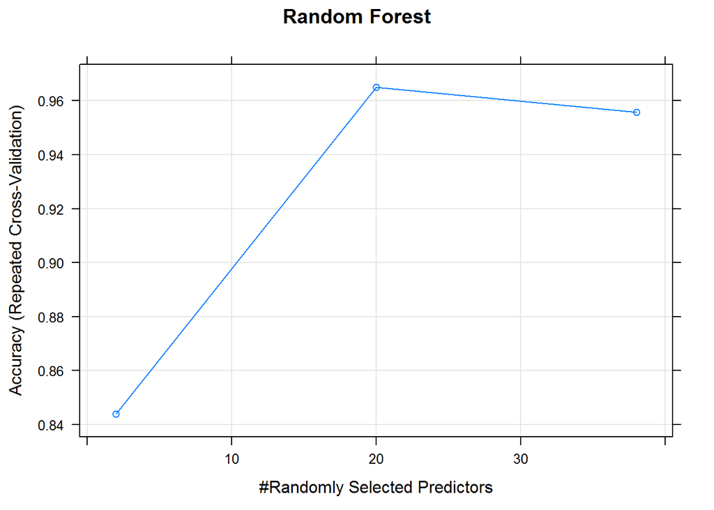

```r
#plotting the model
plot(rfFit, width = 400, height = 300, main = "Random Forest")
```

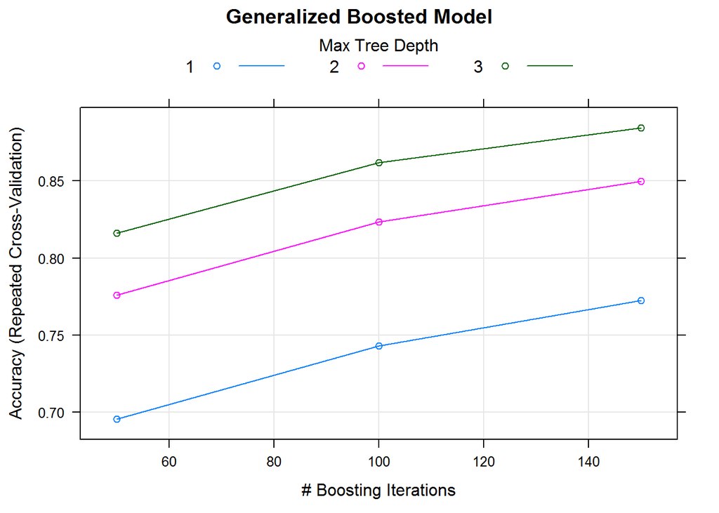

```r
plot(gbmFit, width = 400, height = 300, main = "Generalized Boosted Model")
```

Based on the graphs above, it does seem like Random Forest performed better. But let’s investigate further

```r
#concatenating the fitted models into a single vector
model <- c("Random Forest","Generalized Boosted Model")
#Comparing the models to get the best fitted model
accuracy <- c(max(rfFit$results$Accuracy),
              max(gbmFit$results$Accuracy))

kappa <- c(max(rfFit$results$Kappa),
           max(gbmFit$results$Kappa))

#gathering accuracy info into a data frame
performance <- data.frame(model, accuracy, kappa)
performance
```

```
##                       model  accuracy     kappa
## 1             Random Forest 0.9649712 0.9556954
## 2 Generalized Boosted Model 0.8845898 0.8541600
```

```r
#Based on the measure of accuracy, random forest outperformed boosted trees
#So we predict using the RF moel on the test set
testsetPC$pred <- predict(rfFit, testsetPC)

#Let's build a confusion matrix to further check the model performance
cfm <-confusionMatrix(testsetPC$classe,testsetPC$pred)
cfm
```

```
## Confusion Matrix and Statistics
##
##           Reference
## Prediction    A    B    C    D    E
##          A 2187   31   14    0    0
##          B   36 1444   38    0    0
##          C    1   32 1325   10    0
##          D    0    1   38 1226   21
##          E    0    0    4   12 1426
##
## Overall Statistics
##
##                Accuracy : 0.9697
##                  95% CI : (0.9656, 0.9733)
##     No Information Rate : 0.2835
##     P-Value [Acc > NIR] : < 2.2e-16
##
##                   Kappa : 0.9616
##  Mcnemar's Test P-Value : NA
##
## Statistics by Class:
##
##                      Class: A Class: B Class: C Class: D Class: E
## Sensitivity            0.9834   0.9576   0.9338   0.9824   0.9855
## Specificity            0.9920   0.9883   0.9933   0.9909   0.9975
## Pos Pred Value         0.9798   0.9513   0.9686   0.9533   0.9889
## Neg Pred Value         0.9934   0.9899   0.9855   0.9966   0.9967
## Prevalence             0.2835   0.1922   0.1809   0.1591   0.1844
## Detection Rate         0.2787   0.1840   0.1689   0.1563   0.1817
## Detection Prevalence   0.2845   0.1935   0.1744   0.1639   0.1838
## Balanced Accuracy      0.9877   0.9729   0.9635   0.9866   0.9915
```

## Make a sactter plot comparing observed and predicted outcome

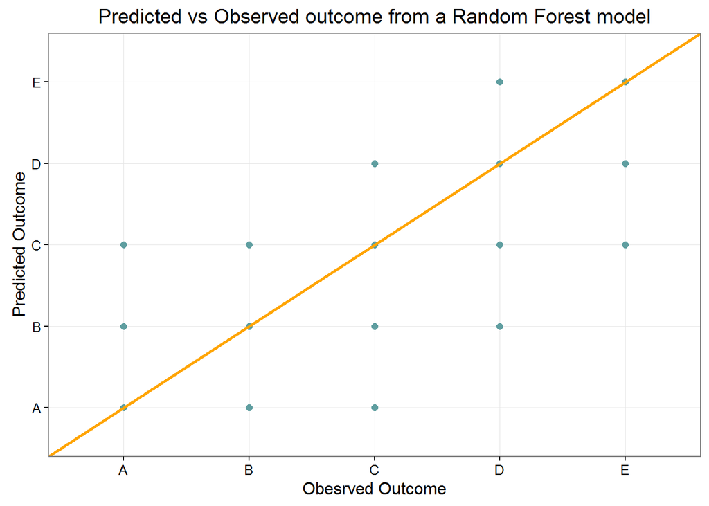

```r
p <- ggplot(testsetPC, aes(classe, pred)) + geom_point(color="cadetblue", size=2)
p <- p + geom_abline(intercept = 0, slope = 1, color = "orange", size = 1)
p <- p + xlab("Obesrved Outcome") + ylab("Predicted Outcome")
p <- p + ggtitle("Predicted vs Observed outcome from a Random Forest model")
p <- p + theme_bw()
print(p)
```

### Reference

The data for this project come from this source: http://groupware.les.inf.puc-rio.br/har. If you use the document you create for this class for any purpose please cite them as they have been very generous in allowing their data to be used for this kind of assignment.